# Week11_final

Предположим, перед вами стоят следующие задачи:

- есть растения нескольких сортов, нужно выделить признаки, характеризующие каждый сорт
- есть ряд диагнозов, необходимо определить симптомы, соответствующие диагнозу
- есть база клиентов с указанием, кто продолжает пользоваться сервисоами компании, а кто ушел. Нужно выделить признаки, которые позволят выявить “проблемных” клиентов

Подобные задачи делятся на две групы: задачи регрессии и задачи классификации. Задача классификации возникает в том случае, если интересующим нас показателем является принадлежность в некоторому классу (болен/не болен, спам/не спам, ушел/остался, высокий/средний/низкий…) – т.е. категориальная переменная.

Про задачу регрессии мы говорим тогда, когда мы хотим предсказать некий количественный, числовой показатель (уровень продаж, рейтинг, риск заразиться…).

Рассмотрим, как подобные задачи можно решать с помощью R.

Первый датасет, с которым мы будем работать содержит данные о пассажирах Титаника. О датасете https://www.kaggle.com/c/titanic/data Когда Титаник затонул, 1502 из 2224 пассажиров и членов экипажа погибли. Одна из главных причин такого большого числа жертв - нехватка спасательных жилетов на корабле. Те, кто смотрел фильм, знают, что шанс одних пассажиров выжить был больше (Роуз), чем других (бедный Джек). Далее мы применим техники машинного обучения для предсказания шанса выжить для каждого пассажира.

Загрузим данные и разделим их на **обучающую (train)** и **тестовую (test)** выборки. На первой вы будете строить модель, а на второй оценивать качество предсказания. Тестовая выборка будет содержать 20% данных

```r
titanic <- read.csv("/principal/courses/minor2_2016/lab10-tree2/Titanic.csv")
str(titanic)
```

```
## 'data.frame':    891 obs. of  12 variables:
##  $ PassengerId: int  1 2 3 4 5 6 7 8 9 10 ...
##  $ Survived   : int  0 1 1 1 0 0 0 0 1 1 ...
##  $ Pclass     : int  3 1 3 1 3 3 1 3 3 2 ...
##  $ Name       : Factor w/ 891 levels "Abbing, Mr. Anthony",..: 109 191 358 277 16 559 520 629 416 581 ...
##  $ Sex        : Factor w/ 2 levels "female","male": 2 1 1 1 2 2 2 2 1 1 ...
##  $ Age        : num  22 38 26 35 35 NA 54 2 27 14 ...
##  $ SibSp      : int  1 1 0 1 0 0 0 3 0 1 ...
##  $ Parch      : int  0 0 0 0 0 0 0 1 2 0 ...
##  $ Ticket     : Factor w/ 681 levels "110152","110413",..: 525 596 662 50 473 276 86 396 345 133 ...
##  $ Fare       : num  7.25 71.28 7.92 53.1 8.05 ...
##  $ Cabin      : Factor w/ 148 levels "","A10","A14",..: 1 83 1 57 1 1 131 1 1 1 ...
##  $ Embarked   : Factor w/ 4 levels "","C","Q","S": 4 2 4 4 4 3 4 4 4 2 ...
```

```r
titanic$Pclass <- as.factor(titanic$Pclass)
titanic$Survived <- as.factor(titanic$Survived)
```

Сначала посчитаем, сколько строк составят 20% от данных

```r
test_size = nrow(titanic)*0.20
test_size
```

```
## [1] 178.2
```

Теперь отберем 178.2 номеров строк случайным образом

```r
set.seed(1238)
test_indices = sample(1:dim(titanic)[1], test_size)
head(test_indices, 20)
```

```
##  [1] 801 672 319 185 164 759 577 196  51 578  70 280 789 834 519 357 226
## [18] 817 765 460
```

Затем в качестве тестовой выборки возьмем те строки, номера которых “выпали”

```r
test_data = titanic[test_indices,]
```

А в качестве обучающей – все, кроме них

```r
train_data = titanic[-test_indices,]
```

Как много людей в вашей тренировачной выборке выжили? Чтобы узнать это используйте команду table() в комбинации с $-оператором для выбора колонки из таблицы.

```r
# Число выживших в абсолютных числах
table(train_data$Survived)
```

```
##
##   0   1
## 439 274
```

```r
# В пропорциях
prop.table(table(train_data$Survived))
```

```
##
##         0         1
## 0.6157083 0.3842917
```

Теперь видно, что 439 человек погибли (62%) и 274 выжили (38%).

В целом, команда table() может помочь вам выявить какие переменные имеют предсказательную силу. Например, может быть пол имеет значение для предсказания? Для включения гендера в сравнение используйте следующий код

```r
table(train_data$Sex, train_data$Survived)
```

```
##
##            0   1
##   female  65 185
##   male   374  89
```

Для получения пропорций заверните table() в prop.table(), но нужно будет уточнить какую пропорцию вы хотите: построчную или колоночную. Для этого включите в prop.table() аргумент margin и определите его значение как 1 или 2 соответственно.

```r
prop.table(table(train_data$Sex, train_data$Survived), 1)
```

```
##
##                  0         1
##   female 0.2600000 0.7400000
##   male   0.8077754 0.1922246
```

Еще одна переменная, которая может повлиять на выживаемость - возраст: возможно, детей спасали в первую очередь. Вы проверите это, создав категориальную переменную child.

```r
# Создаем переменную
train_data$Child <- NA
train_data$Child[train_data$Age < 18] <- 1
train_data$Child[train_data$Age >= 18] <- 0

# Двусторонее сравнение
prop.table(table(train_data$Child, train_data$Survived), 1)
```

```
##
##             0         1
##   0 0.6296296 0.3703704
##   1 0.4117647 0.5882353
```

До настоящего момента вы проделали определенные манипуляции, чтобы найти сабсеты, имеющие больший шанс выжить (женщины и дети). Дерево решений автоматизирует этот процесс и в результате вы получаете блок-схему, которая легко интерпретируется.

Концептуально алгоритм дерева решений делит исходный набор данных на подмножества, которые становятся все более и более гомогенными относительно определенных признаков, в результате чего формируется древовидная иерархическая структура. Алгоритм начинает со всех данных в корневом узле и сканирует все переменные, выбирая лучшую из них для разделения. Как только переменная выбрана, происходит разделение и переход на один уровень (или узел) ниже, далее эта процедура повторяется. Конечные узлы дерева называются терминальными (terminal nodes) или листьями (leaves).

Для построения первого дерева решений мы будем использовать пакет rpart. Подробнее про пакет бы можете прочитать здесь https://cran.r-project.org/web/packages/rpart/rpart.pdf

```r
library(rpart)
```

Внутри rpart, есть функция rpart(), с помощью которой мы и построим дерево решений. Функция включает следующие аргументы:

**formula:** специфицирует интересующую переменную (Dependent variable) и переменные, используемые для предсказания (Independent variables)

например, formula = Survived ~ Sex + Age

Если хотите построить дерево, используя все переменные, то после знака “~” поставьте точку, вы получите следующую формулу formula = Survived ~.

**data:** датасет для построения дерева (у нас это train_data).

**method:** тип предсказания. Мы хотим предсказать категориальную переменную, это задача классификации: method = “class”.

Чтобы визуализировать полученное дерево вы можете использовать prp(my_tree) из пакета rpart.plot.

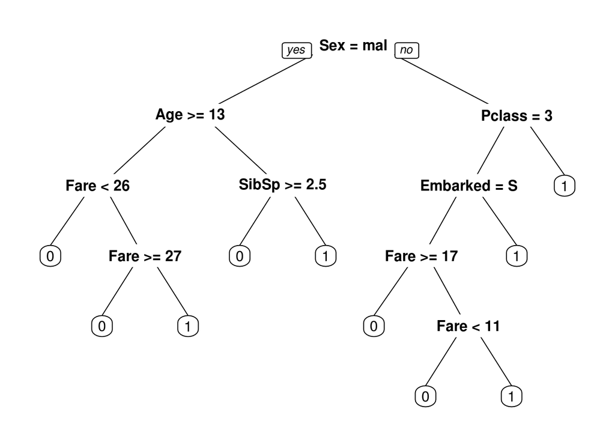

```r
# Build the decision tree
my_tree <- rpart(Survived ~ Pclass + Sex + Age + SibSp + Parch + Fare + Embarked, data = train_data, method = "class")

# Визуализируем дерево решений
library(rpart.plot)
prp(my_tree)
```

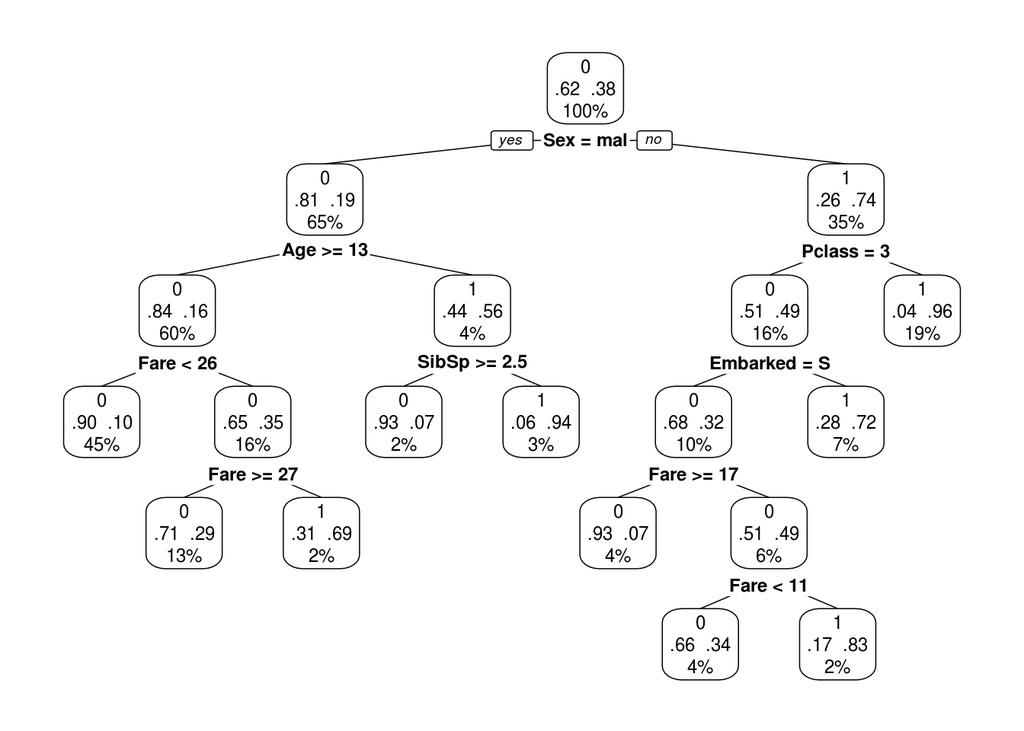

```r
# Добавим больше информативности
prp(my_tree, type=2, extra=104)
```

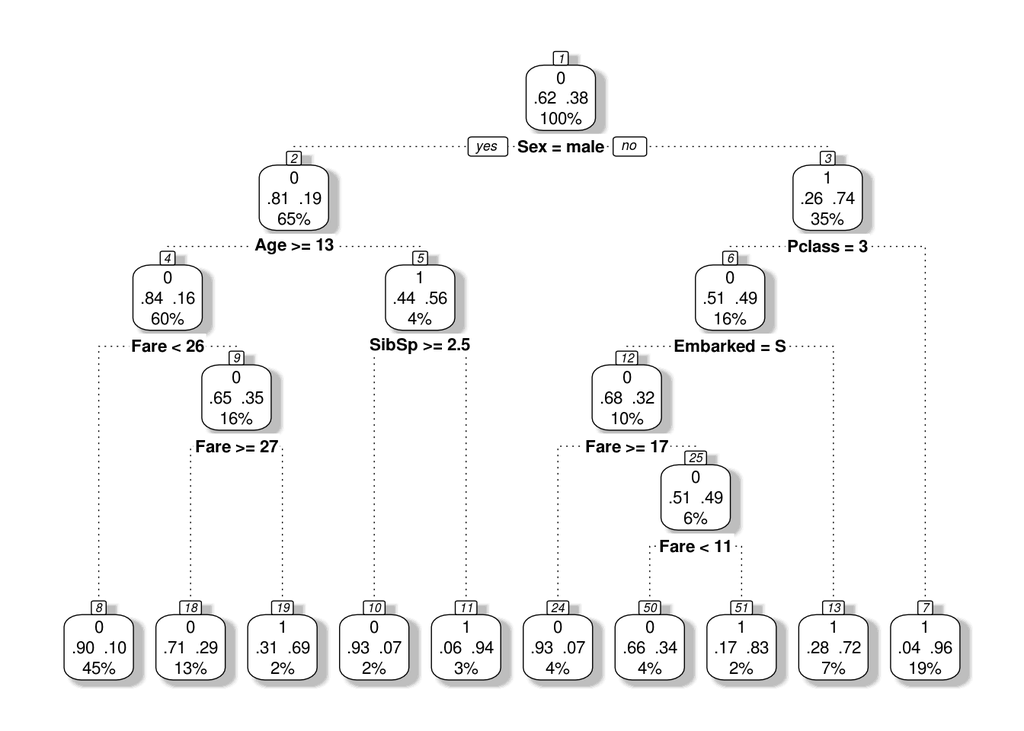

```r
prp(my_tree, type=2, extra=104, nn=TRUE, fallen.leaves=TRUE,faclen=0, varlen=0, shadow.col="grey", branch.lty=3)
```

Каждый терминальный узел помечен предсказанным классом (0 - не выжил, 1 - выжил). Все узлы размещены по принципу падающих листьев (fallen.leaves=TRUE), чтобы визуально усилить структуру. Мы видим прямые линии сверху вниз, что позволяет быстро принять решение. Каждый узел содержит вероятность для каждого класса и процент наблюдений ассоциируемый с узлом (extra=104). Включены номера узлов (nn=TRUE), это позволяет перекрестно ссылаться на каждый узел дерева. Использование пунктирной линии (branch.lty=3) переключает внимание с тяжелых линий и фокусирует его на узлах, при этом все еще четко можно проследить связи. Серая тень - приятное дополнение.

Множество способов визуализации с помощью prp() описано здесь http://www.academia.edu/6241482/Data_Science_with_R_Decision_Trees

Основываясь на построенном дереве решений определите, какие переменные играют наибольшую роль в определении того выживет ли пассажир?

**Варианты ответа**

Sex, Age, Pclass, SibSp, Parch, Fare and Embarked

Sex, Age, Pclass, SibSp, Embarked, Fare - верный

Sex, Age, Parch and Embarked

Sex, Age and Embarked